# Large scale text analysis with deep learning

В этой лабораторной работе я постаралась выполнить все задания, которые нам дали.

Сначала я попробовала прогнать модель без каких-либо преобразований, чтобы понимать, с чего мы начинаем.

Затем поочередно добавляла BatchNorm, GroupNorm, LayerNorm (LayerNorm, в отличии от других, я доабвляла перед Encoder).

Пробовала добавлять слои разной размерности, экспериментировала с параметрами Conv1d.

Использовала EarlyStopping.

Применяла разные пуллинги, в том числе Softmax Pooling и Attentive Pooling.

Также попробовала скачать две разные модели с предобученными эмбеддингами (Twitter & Wikipedia), тренируя с замороженными и обучаемыми весами.

Посмотрела, что будет, если заменить сверточные сети на рекуррентные (LSTM, GRU), а также что будет при использование комбинаций из рекуррентных и сверточных сетей.

Попробовала вытащить признаки с последнего слоя модели и прогнать через Decision Tree & Random Forest.

```python
from google.colab import drive
drive.mount('/content/gdrive')
```

```python
import numpy as np
import pandas as pd
import matplotlib.pyplot as plt
%matplotlib inline
```

### About the challenge

For starters, let's download and unpack the data from [here].

You can also get it from [yadisk url](https://yadi.sk/d/vVEOWPFY3NruT7) the competition [page](https://www.kaggle.com/c/job-salary-prediction/data) (pick `Train_rev1.*`).

```python
data = pd.read_csv("/content/gdrive/MyDrive/Colab Notebooks/Train_rev1.csv", index_col=None)
# !unzip Train_rev1.zip
# data = pd.read_csv("Train_rev1.csv", index_col=None)
data.shape
```

```
(244768, 12)
```

```python
data.head()
```

|  | Id | Title | FullDescription | LocationRaw | LocationNormalized | ContractType | ContractTime | Company | Category | SalaryRaw | SalaryNormalized | SourceName |
| --- | --- | --- | --- | --- | --- | --- | --- | --- | --- | --- | --- | --- |
| 0 | 12612628 | Engineering Systems Analyst | Engineering Systems Analyst Dorking Surrey Sal... | Dorking, Surrey, Surrey | Dorking | NaN | permanent | Gregory Martin International | Engineering Jobs | 20000 - 30000/annum 20-30K | 25000 | cv-library.co.uk |
| 1 | 12612830 | Stress Engineer Glasgow | Stress Engineer Glasgow Salary **** to **** We... | Glasgow, Scotland, Scotland | Glasgow | NaN | permanent | Gregory Martin International | Engineering Jobs | 25000 - 35000/annum 25-35K | 30000 | cv-library.co.uk |
| 2 | 12612844 | Modelling and simulation analyst | Mathematical Modeller / Simulation Analyst / O... | Hampshire, South East, South East | Hampshire | NaN | permanent | Gregory Martin International | Engineering Jobs | 20000 - 40000/annum 20-40K | 30000 | cv-library.co.uk |
| 3 | 12613049 | Engineering Systems Analyst / Mathematical Mod... | Engineering Systems Analyst / Mathematical Mod... | Surrey, South East, South East | Surrey | NaN | permanent | Gregory Martin International | Engineering Jobs | 25000 - 30000/annum 25K-30K negotiable | 27500 | cv-library.co.uk |
| 4 | 12613647 | Pioneer, Miser Engineering Systems Analyst | Pioneer, Miser Engineering Systems Analyst Do... | Surrey, South East, South East | Surrey | NaN | permanent | Gregory Martin International | Engineering Jobs | 20000 - 30000/annum 20-30K | 25000 | cv-library.co.uk |

One problem with salary prediction is that it's oddly distributed: there are many people who are paid standard salaries and a few that get tons o money. The distribution is fat-tailed on the right side, which is inconvenient for MSE minimization.

There are several techniques to combat this: using a different loss function, predicting log-target instead of raw target or even replacing targets with their percentiles among all salaries in the training set. We gonna use logarithm for now.

*You can read more [in the official description](https://www.kaggle.com/c/job-salary-prediction#description).*

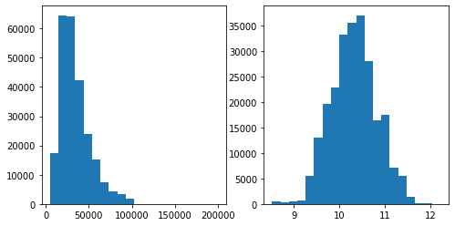

```python
data['Log1pSalary'] = np.log1p(data['SalaryNormalized']).astype('float32')

plt.figure(figsize=[8, 4])
plt.subplot(1, 2, 1)
plt.hist(data["SalaryNormalized"], bins=20);

plt.subplot(1, 2, 2)
plt.hist(data['Log1pSalary'], bins=20);
```

Our task is to predict one number, **Log1pSalary**.

To do so, our model can access a number of features:

- Free text: **`Title`** and **`FullDescription`**
- Categorical: **`Category`**, **`Company`**, **`LocationNormalized`**, **`ContractType`**, and **`ContractTime`**.

```python
text_columns = ["Title", "FullDescription"]
categorical_columns = ["Category", "Company", "LocationNormalized", "ContractType", "ContractTime"]
TARGET_COLUMN = "Log1pSalary"

data[categorical_columns] = data[categorical_columns].fillna('NaN') # cast missing values to string "NaN"
data[text_columns] = data[text_columns].fillna('NaN')

data.sample(3)
```

|  | Id | Title | FullDescription | LocationRaw | LocationNormalized | ContractType | ContractTime | Company | Category | SalaryRaw | SalaryNormalized | SourceName | Log1pSalary |
| --- | --- | --- | --- | --- | --- | --- | --- | --- | --- | --- | --- | --- | --- |
| 232049 | 72460737 | Film Game Sales Assistant | Film Game Sales Assistant Trainee Sales Assis... | Sheffield, Doncaster, Rotherham, South Yorkshi... | UK | NaN | NaN | Unique Client Solutions | Creative & Design Jobs | 250-400 per week -OTE | 15600 | jobsite.co.uk | 9.655090 |
| 184685 | 71659200 | Restaurant Manager | Restaurant Manager Manchester This **** star ... | Manchester, Lancashire, UK, Lancashire | UK | NaN | NaN | Appetite 4 Recruitment | Hospitality & Catering Jobs | 26000.00 - 27000.00 per annum | 26500 | jobs.catererandhotelkeeper.com | 10.184937 |
| 41496 | 68393489 | Assistant Assurance Manager 12 Months Fixed T... | The role holder will report to the Assurance M... | London | London | NaN | NaN | PSD Risk | Accounting & Finance Jobs | 50,000 - 75,000 | 62500 | eFinancialCareers | 11.042938 |

### Preprocessing text data

Just like last week, applying NLP to a problem begins from tokenization: splitting raw text into sequences of tokens (words, punctuation, etc).

**Your task** is to lowercase and tokenize all texts under `Title` and `FullDescription` columns. Store the tokenized data as a **space-separated** string of tokens for performance reasons.

It's okay to use nltk tokenizers. Assertions were designed for WordPunctTokenizer, slight deviations are okay.

```python
print("Raw text:")
print(data["FullDescription"][2::100000])
```

```
Raw text:
2         Mathematical Modeller / Simulation Analyst / O...
100002    A successful and high achieving specialist sch...
200002    Web Designer  HTML, CSS, JavaScript, Photoshop...
Name: FullDescription, dtype: object
```

```python
import nltk
#TODO YOUR CODE HERE

tokenizer = nltk.tokenize.WordPunctTokenizer()
# YOUR CODE HERE

data[text_columns] = data[text_columns].applymap(lambda x: " ".join(tokenizer.tokenize(x.lower())))
```

Now we can assume that our text is a space-separated list of tokens:

```python
print("Tokenized:")
print(data["FullDescription"][2::100000])
assert data["FullDescription"][2][:50] == 'mathematical modeller / simulation analyst / opera'
assert data["Title"][54321] == 'international digital account manager ( german )'
```

```
Tokenized:
2         mathematical modeller / simulation analyst / o...
100002    a successful and high achieving specialist sch...
200002    web designer html , css , javascript , photosh...
Name: FullDescription, dtype: object
```

Not all words are equally useful. Some of them are typos or rare words that are only present a few times.

Let's count how many times is each word present in the data so that we can build a "white list" of known words.

```python
from collections import Counter
token_counts = Counter()
# Count how many times does each token occur in both "Title" and "FullDescription" in total
#TODO <YOUR CODE>

for col in text_columns:
    for line in data[col].values:
        token_counts.update(line.split(" "))
```

```python
print("Total unique tokens :", len(token_counts))
print('\n'.join(map(str, token_counts.most_common(n=5))))
print('...')
print('\n'.join(map(str, token_counts.most_common()[-3:])))

assert token_counts.most_common(1)[0][1] in  range(2600000, 2700000)
assert len(token_counts) in range(200000, 210000)
print('Correct!')
```

```
Total unique tokens : 202704
('and', 2657388)
('.', 2523216)
(',', 2318606)
('the', 2080994)
('to', 2019884)
...
('stephanietraveltraderecruitmnt', 1)
('ruabon', 1)
('lowehays', 1)
Correct!
```

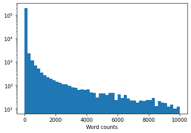

```python
# Let's see how many words are there for each count
plt.hist(list(token_counts.values()), range=[0, 10**4], bins=50, log=True)
plt.xlabel("Word counts");
```

**Task 1.1** Get a list of all tokens that occur at least 10 times.

```python
min_count = 10

# tokens from token_counts keys that had at least min_count occurrences throughout the dataset
#TODO <YOUR CODE>
tokens = sorted(t for t, c in token_counts.items() if c >= min_count)

# Add a special tokens for unknown and empty words
UNK, PAD = "UNK", "PAD"
tokens = [UNK, PAD] + tokens
```

```python
print("Vocabulary size:", len(tokens))
assert type(tokens) == list
assert len(tokens) in range(32000, 35000)
assert 'me' in tokens
assert UNK in tokens
print("Correct!")
```

```
Vocabulary size: 34158
Correct!
```

**Task 1.2** Build an inverse token index: a dictionary from token(string) to it's index in `tokens` (int)

```python
# TODO <YOUR CODE>
token_to_id = {t: i for i, t in enumerate(tokens)}
```

```python
assert isinstance(token_to_id, dict)
assert len(token_to_id) == len(tokens)
for tok in tokens:
    assert tokens[token_to_id[tok]] == tok

print("Correct!")
```

```
Correct!
```

And finally, let's use the vocabulary you've built to map text lines into neural network-digestible matrices.

```python
UNK_IX, PAD_IX = map(token_to_id.get, [UNK, PAD])

def as_matrix(sequences, max_len=None):
    """ Convert a list of tokens into a matrix with padding """
    if isinstance(sequences[0], str):
        sequences = list(map(str.split, sequences))

    max_len = min(max(map(len, sequences)), max_len or float('inf'))

    matrix = np.full((len(sequences), max_len), np.int32(PAD_IX))
    for i,seq in enumerate(sequences):
        row_ix = [token_to_id.get(word, UNK_IX) for word in seq[:max_len]]
        matrix[i, :len(row_ix)] = row_ix

    return matrix
```

```python
print("Lines:")
print('\n'.join(data["Title"][::100000].values), end='\n\n')
print("Matrix:")
print(as_matrix(data["Title"][::100000]))
```

```
Lines:
engineering systems analyst
hr assistant
senior ec & i engineer

Matrix:
[[10807 30161  2166     1     1]
 [15020  2844     1     1     1]
 [27645 10201    16 15215 10804]]
```

Now let's encode the categirical data we have.

As usual, we shall use one-hot encoding for simplicity. Kudos if you implement more advanced encodings: tf-idf, pseudo-time-series, etc.

```python
from sklearn.feature_extraction import DictVectorizer

# we only consider top-1k most frequent companies to minimize memory usage
top_companies, top_counts = zip(*Counter(data['Company']).most_common(1000))
recognized_companies = set(top_companies)
data["Company"] = data["Company"].apply(lambda comp: comp if comp in recognized_companies else "Other")

categorical_vectorizer = DictVectorizer(dtype=np.float32, sparse=False)
categorical_vectorizer.fit(data[categorical_columns].apply(dict, axis=1))
```

```
DictVectorizer(dtype=<class 'numpy.float32'>, sparse=False)
```

### The deep learning part

Once we've learned to tokenize the data, let's design a machine learning experiment.

As before, we won't focus too much on validation, opting for a simple train-test split.

**To be completely rigorous,** we've comitted a small crime here: we used the whole data for tokenization and vocabulary building. A more strict way would be to do that part on training set only. You may want to do that and measure the magnitude of changes.

```python
from sklearn.model_selection import train_test_split

data_train, data_val = train_test_split(data, test_size=0.1, random_state=77)
data_train.index = range(len(data_train))
data_val.index = range(len(data_val))

print("Train size = ", len(data_train))
print("Validation size = ", len(data_val))
```

```
Train size =  220291
Validation size =  24477
```

```python
import torch

def to_tensors(batch, device):
    batch_tensors = dict()
    for key, arr in batch.items():
        if key in ["FullDescription", "Title"]:
            batch_tensors[key] = torch.tensor(arr, device=device, dtype=torch.int64)
        else:
            batch_tensors[key] = torch.tensor(arr, device=device)
    return batch_tensors

def make_batch(data, max_len=None, word_dropout=0, device=torch.device('cpu')):
    """
    Creates a keras-friendly dict from the batch data.
    :param word_dropout: replaces token index with UNK_IX with this probability
    :returns: a dict with {'title' : int64[batch, title_max_len]
    """
    batch = {}
    batch["Title"] = as_matrix(data["Title"].values, max_len)
    batch["FullDescription"] = as_matrix(data["FullDescription"].values, max_len)
    batch['Categorical'] = categorical_vectorizer.transform(data[categorical_columns].apply(dict, axis=1))

    if word_dropout != 0:
        batch["FullDescription"] = apply_word_dropout(batch["FullDescription"], 1. - word_dropout)

    if TARGET_COLUMN in data.columns:
        batch[TARGET_COLUMN] = data[TARGET_COLUMN].values

    return to_tensors(batch, device)

def apply_word_dropout(matrix, keep_prop, replace_with=UNK_IX, pad_ix=PAD_IX,):
    dropout_mask = np.random.choice(2, np.shape(matrix), p=[keep_prop, 1 - keep_prop])
    dropout_mask &= matrix != pad_ix
    return np.choose(dropout_mask, [matrix, np.full_like(matrix, replace_with)])
```

```python
make_batch(data_train[:3], max_len=10)
```

```
{'Categorical': tensor([[0., 0., 0.,  ..., 0., 0., 0.],
         [0., 0., 0.,  ..., 0., 0., 0.],
         [0., 0., 0.,  ..., 0., 0., 0.]]),
 'FullDescription': tensor([[32937, 31100, 33664, 12587,   982, 17753, 11192,  1693,   943,  8110],
         [ 2572, 33996,   982, 13650,   158, 33554,   982,   437, 22021,    82],
         [33996, 33435, 30323, 33554,  3002, 20893, 11312,   158,  7151, 31100]]),
 'Log1pSalary': tensor([10.5967,  9.5325, 10.4631]),
 'Title': tensor([[27645, 26986,  1587,   197, 11192,  1700],
         [27280, 13650, 30409,  2844,     1,     1],
         [ 4986,  9083, 18864,     1,     1,     1]])}
```

```python
import torch
import torch.nn as nn
import torch.functional as F
```

```python
#  Понимаю, что так выглядит менее читабельно, но мне хотелось, чтобы все было в одном месте

class SalaryPredictor(nn.Module):
    def __init__(self, n_tokens=len(tokens), n_cat_features=len(categorical_vectorizer.vocabulary_),
                 norm='batch', pool=nn.AdaptiveMaxPool1d, conv_layers=1,
                 hid_size=8, groups=1, pretrained=False, grad=False, weights=None, rnn=False,
                 lstm_title=False, gru_title=False, lstm_desc=False, gru_desc=False,
                 third_layer_out=None, second_layer_out=None,
                 layers=0, bidirectional=False, mix=False, final_const=4):
      super().__init__()
      self.conv_layers = conv_layers

      if norm == 'layer':
        self.layernorm = nn.LayerNorm(hid_size)
      else:
        self.layernorm = None

      if third_layer_out != None:
        self.third_out = third_layer_out
      else:
        self.third_out = hid_size

      if second_layer_out != None:
        self.sec_out = second_layer_out
      else:
        self.sec_out = hid_size

      if pretrained == False:
        self.embedder = nn.Embedding(n_tokens, hid_size)
      else:
        self.embedder = nn.Embedding.from_pretrained(weights)
        self.embedder.requires_grad = grad

      if conv_layers == 3:
        self.additional_title_encoder_third = nn.Sequential(
          nn.Conv1d(hid_size, self.third_out, kernel_size=2),
          nn.BatchNorm1d(self.third_out),
          nn.Dropout(p=0.25)
        )
        self.additional_description_encoder_third = nn.Sequential(
          nn.Conv1d(hid_size, self.third_out, kernel_size=2),
          nn.BatchNorm1d(self.third_out),
          nn.Dropout(p=0.25)
        )

      if conv_layers >= 2:
        self.additional_title_encoder = nn.Sequential(
          nn.Conv1d(self.third_out, self.sec_out, kernel_size=2),
          nn.BatchNorm1d(self.sec_out),
          nn.Dropout(p=0.25)
        )
        self.additional_description_encoder = nn.Sequential(
          nn.Conv1d(self.third_out, self.sec_out, kernel_size=2),
          nn.BatchNorm1d(self.sec_out),
          nn.Dropout(p=0.25)
        )

      if norm == 'group':
        self.title_encoder = nn.Sequential(
          nn.Conv1d(self.sec_out, hid_size, kernel_size=2, groups=groups),
          nn.GroupNorm(1, hid_size),
          nn.Dropout(p=0.25),
          nn.ReLU()
        )
        self.description_encoder = nn.Sequential(
          nn.Conv1d(self.sec_out, hid_size, kernel_size=2, groups=groups),
          nn.GroupNorm(1, hid_size),
          nn.Dropout(p=0.25),
          nn.ReLU()
          )
      elif norm == 'batch':
        self.title_encoder = nn.Sequential(
            nn.Conv1d(self.sec_out, hid_size, kernel_size=2, groups=groups),
            nn.BatchNorm1d(hid_size),
            nn.Dropout(p=0.25),
            nn.ReLU()
        )
        self.description_encoder = nn.Sequential(
            nn.Conv1d(self.sec_out, hid_size, kernel_size=2, groups=groups),
            nn.BatchNorm1d(hid_size),
            nn.Dropout(p=0.25),
            nn.ReLU()
        )
      else:
        self.title_encoder = nn.Sequential(
          nn.Conv1d(self.sec_out, hid_size, kernel_size=2, groups=groups),
          nn.Dropout(p=0.25),
          nn.ReLU()
        )
        self.description_encoder = nn.Sequential(
          nn.Conv1d(self.sec_out, hid_size, kernel_size=2, groups=groups),
          nn.Dropout(p=0.25),
          nn.ReLU()
        )
      self.pooling = pool(output_size=1)
      self.categorical_encoder = nn.Sequential(
          nn.Linear(n_cat_features, hid_size * 2),
          nn.ReLU(),
          nn.Linear(hid_size * 2, hid_size * 2),
          nn.ReLU()
      )
      self.prefinal_predictor = nn.Sequential(
          nn.Linear(final_const * hid_size, hid_size),
          nn.ReLU()
      )
      self.final_predictor = nn.Linear(hid_size, 1)
      self.sublayer = nn.Sequential(
          nn.Dropout(p=0.25),
          nn.ReLU(),
          pool(output_size=1)
      )

      self.rnn_title = False
      self.rnn_desc = False
      self.mix = mix


      if rnn == True:

        if lstm_title == True or gru_title == True:
          self.rnn_title = True
        if lstm_desc == True or gru_desc == True:
          self.rnn_desc = True

        if lstm_title == True:
          self.title_rnn = nn.LSTM(input_size=hid_size, hidden_size=hid_size, num_layers=layers, bidirectional=bidirectional)
        if lstm_desc == True:
          self.descr_rnn = nn.LSTM(input_size=hid_size, hidden_size=hid_size, num_layers=layers, bidirectional=bidirectional)
        if gru_title == True:
          self.title_rnn = nn.GRU(input_size=hid_size, hidden_size=hid_size, num_layers=layers, bidirectional=bidirectional)
        if gru_desc == True:
          self.descr_rnn = nn.GRU(input_size=hid_size, hidden_size=hid_size, num_layers=layers, bidirectional=bidirectional)

    def forward(self, batch):

      if self.rnn_title == True:
        title_embeddings = self.embedder(batch['Title'])

        if self.mix == True:
          title_embeddings = self.title_encoder(title_embeddings.permute(0, 2, 1)).permute(0, 2, 1)

        title_features, (hn, cn) = self.title_rnn(title_embeddings)
        title_features = self.sublayer(title_features.permute(0, 2, 1)).squeeze()

      else:
        title_embeddings = self.embedder(batch['Title']).permute(0, 2, 1)
        if self.layernorm != None:
          title_embeddings = self.layernorm(title_embeddings.permute(0, 2, 1)).permute(0, 2, 1)
        if self.conv_layers == 3:
          title_embeddings = self.additional_title_encoder_third(title_embeddings)
        if self.conv_layers >= 2:
          title_embeddings = self.additional_title_encoder(title_embeddings)
        title_features = self.title_encoder(title_embeddings)
        title_features = self.pooling(title_features).squeeze()

      if self.rnn_desc == True:
        description_embeddings = self.embedder(batch['FullDescription'])

        if self.mix == True:
          description_embeddings = self.description_encoder(description_embeddings.permute(0, 2, 1)).permute(0, 2, 1)

        description_features, (hn, cn) = self.descr_rnn(description_embeddings)
        description_features = self.sublayer(description_features.permute(0, 2, 1)).squeeze()

      else:
        description_embeddings = self.embedder(batch['FullDescription']).permute(0, 2, 1)
        if self.layernorm != None:
          description_embeddings = self.layernorm(description_embeddings.permute(0,2,1)).permute(0,2,1)
        if self.conv_layers == 3:
          description_embeddings = self.additional_description_encoder_third(description_embeddings)
        if self.conv_layers >= 2:
          description_embeddings = self.additional_description_encoder(description_embeddings)
        description_features = self.description_encoder(description_embeddings)
        description_features = self.pooling(description_features).squeeze()

      categorical_features = self.categorical_encoder(batch['Categorical'])

      features = torch.cat(
          [title_features, description_features, categorical_features], dim=1)

      features = self.prefinal_predictor(features)

      return self.final_predictor(features).squeeze()
```

```python
model = SalaryPredictor()
batch = make_batch(data_train[:100])
criterion = nn.MSELoss()

dummy_pred = model(batch)
dummy_loss = criterion(dummy_pred, batch[TARGET_COLUMN])
assert dummy_pred.shape == torch.Size([100])
assert len(np.unique(dummy_pred.detach().numpy())) > 20, "model returns suspiciously few unique outputs. Check your initialization"
assert dummy_loss.ndim == 0 and 0. <= dummy_loss <= 250., "make sure you minimize MSE"
```

#### Training and evaluation

As usual, we gonna feed our monster with random minibatches of data.

As we train, we want to monitor not only loss function, which is computed in log-space, but also the actual error measured in dollars.

```python
def iterate_minibatches(data, batch_size=256, shuffle=True, cycle=False, **kwargs):
    """ iterates minibatches of data in random order """
    while True:
        indices = np.arange(len(data))
        if shuffle:
            indices = np.random.permutation(indices)

        for start in range(0, len(indices), batch_size):
            batch = make_batch(data.iloc[indices[start : start + batch_size]], **kwargs)
            yield batch

        if not cycle: break
```

### Model training

We can now fit our model the usual minibatch way. The interesting part is that we train on an infinite stream of minibatches, produced by `iterate_minibatches` function.

```python
import tqdm

BATCH_SIZE = 128
EPOCHS = 3
DEVICE = torch.device('cuda')
# DEVICE = torch.device('cpu')
```

```python
def print_metrics(model, data, batch_size=BATCH_SIZE, name="", **kw):
    squared_error = abs_error = num_samples = 0.0
    model.eval()
    with torch.no_grad():
        for batch in iterate_minibatches(data, batch_size=batch_size, shuffle=False, **kw):
            batch_pred = model(batch)
            squared_error += torch.mean(torch.square(batch_pred - batch[TARGET_COLUMN]))
            abs_error += torch.mean(torch.abs(batch_pred - batch[TARGET_COLUMN]))
            num_samples += len(batch)
    mse = squared_error.detach().cpu().numpy() / num_samples
    mae = abs_error.detach().cpu().numpy() / num_samples
    print("%s results:" % (name or ""))
    print("Mean square error: %.5f" % mse)
    print("Mean absolute error: %.5f" % mae)
    return mse, mae
```

```python
from IPython.display import clear_output

def train_model(model):

  model = model.to(DEVICE)
  criterion = nn.MSELoss(reduction='mean')
  optimizer = torch.optim.Adam(model.parameters(), lr=1e-3)

  history = []
  mse_er = []
  mae_er = []

  mse_value = mae_value = 0.0

  for epoch in range(EPOCHS):
      print(f"epoch: {epoch}")
      for i, batch in tqdm.notebook.tqdm(enumerate(
              iterate_minibatches(
                      data_train,
                      batch_size=BATCH_SIZE,
                      device=DEVICE)),
                  total=len(data_train) // BATCH_SIZE
          ):
          squared_error = abs_error = 0.0

          model.train()
          pred = model(batch)
          optimizer.zero_grad()
          loss = criterion(pred, batch[TARGET_COLUMN])
          loss.backward()
          optimizer.step()

          squared_error = torch.mean(torch.square(pred - batch[TARGET_COLUMN]))
          abs_error = torch.mean(torch.abs(pred - batch[TARGET_COLUMN]))

          mse_value = squared_error.detach().cpu().numpy() / len(batch)
          mae_value = abs_error.detach().cpu().numpy() / len(batch)

          history.append(loss.item())
          mse_er.append(mse_value)
          mae_er.append(mae_value)

          if (i + 1) % 10 == 0:
            clear_output(True)
            fig, ax = plt.subplots(nrows=1, ncols=3, figsize=(20, 4))
            ax[0].plot(history, label="loss")
            ax[0].set_title('loss')
            ax[1].plot(mse_er, label="mse")
            ax[1].set_title('mse')
            ax[2].plot(mae_er, label="mae")
            ax[2].set_title('mae')
            plt.legend()
            plt.show()

      print("Train Loss:", loss.item())
      print("Train Mean square error: %.5f" % mse_value)
      print("Train Mean absolute error: %.5f" % mae_value)

      print_metrics(model, data_val, name='val', batch_size=BATCH_SIZE, device=DEVICE)

  return model, history
```

**1. Развейте СNN архитектуру (2 балла)**

Для начала хочу посмотреть, как нормализация влияет на результаты.

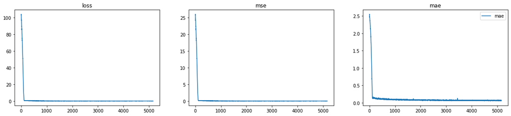

```
Train Loss: 0.7795674800872803
Train Mean square error: 0.19489
Train Mean absolute error: 0.18152
val results:
Mean square error: 0.31205
Mean absolute error: 0.26724
```

```python
model_without_norm = SalaryPredictor(norm='none')
model_without_norm, model_without_norm_plot = train_model(model_without_norm)
```

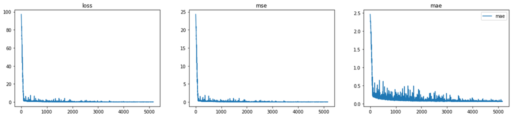

```
Train Loss: 0.043232262134552
Train Mean square error: 0.01081
Train Mean absolute error: 0.04226
val results:
Mean square error: 0.06948
Mean absolute error: 0.10974
```

```python
model_batchnorm = SalaryPredictor(norm='batch')
model_batchnorm, model_batchnorm_plot= train_model(model_batchnorm)
```

В отличии от модели без нормализации, при BatchNorm заметно, что MAE весьма сильно колеблется, впрочем за MSE тоже наблюдается подобное, но результат почти в 3 раза лучше

Как я отмечала ранее, в отличии от других нормализаций LayerNorm я применяла перед Encoder

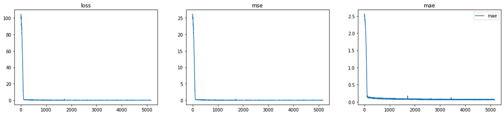

```
Train Loss: 0.05127091333270073
Train Mean square error: 0.01282
Train Mean absolute error: 0.04277
val results:
Mean square error: 0.46033
Mean absolute error: 0.32913
```

```python
model_layernorm = SalaryPredictor(norm='layer')
model_layernorm, model_layernorm_plot= train_model(model_layernorm)
```

По поведению LayerNorm напоминает первую модель, небольшие выбросы наблюдаются только при валидации

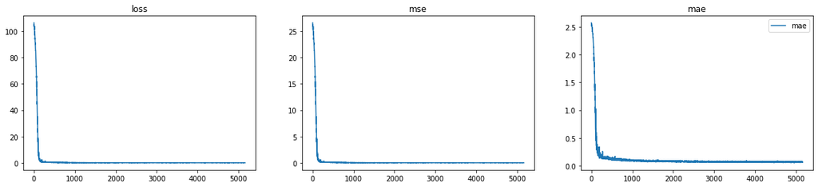

```
Train Loss: 1.023471713066101
Train Mean square error: 0.25587
Train Mean absolute error: 0.23687
val results:
Mean square error: 0.14484
Mean absolute error: 0.17257
```

```python
model_groupnorm = SalaryPredictor(norm='group')
model_groupnorm, model_groupnorm_plot = train_model(model_groupnorm)
```

По результатам можно понять, что при BatchNorm модель показывает результаты гораздо лучше, чем без нее.

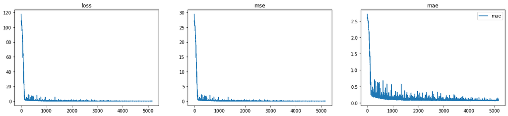

```
Train Loss: 0.12260090559720993
Train Mean square error: 0.03065
Train Mean absolute error: 0.08550
val results:
Mean square error: 0.21810
Mean absolute error: 0.21831
```

```python
model_conv2_16 = SalaryPredictor(conv_layers=2, second_layer_out=16)
model_conv2_16, model_conv2_16_plot = train_model(model_conv2_16)
```

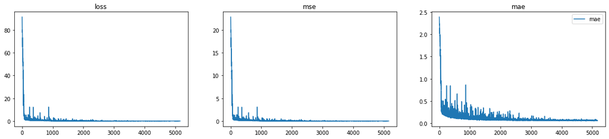

```
Train Loss: 0.28557267785072327
Train Mean square error: 0.07139
Train Mean absolute error: 0.10952
val results:
Mean square error: 0.17250
Mean absolute error: 0.19110
```

```python
model_conv2_32 = SalaryPredictor(conv_layers=2, second_layer_out=32)
model_conv2_32, model_conv2_32_plot = train_model(model_conv2_32)
```

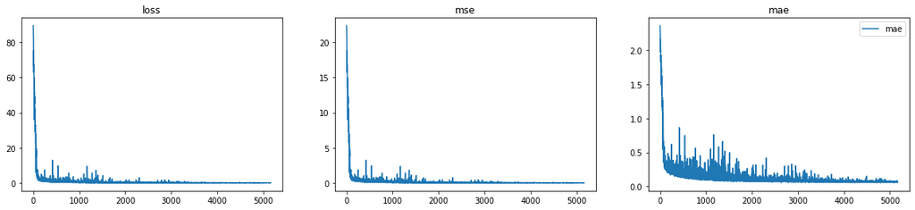

```
Train Loss: 0.29730427265167236
Train Mean square error: 0.07433
Train Mean absolute error: 0.12390
val results:
Mean square error: 0.08148
Mean absolute error: 0.12084
```

```python
model_conv2_norm = SalaryPredictor(conv_layers=2)
model_conv2_norm, model_conv2_norm_plot = train_model(model_conv2_norm)
```

Среди данных экспериментов лучше всего себя показывает сеть с выходом первого слоя 8, а также нормализацией.

Далее я рассматриваю сверточную сеть из 3 слоев с разными выходами на 1 и 2 слоях, везде использую нормализацию BatchNorm:

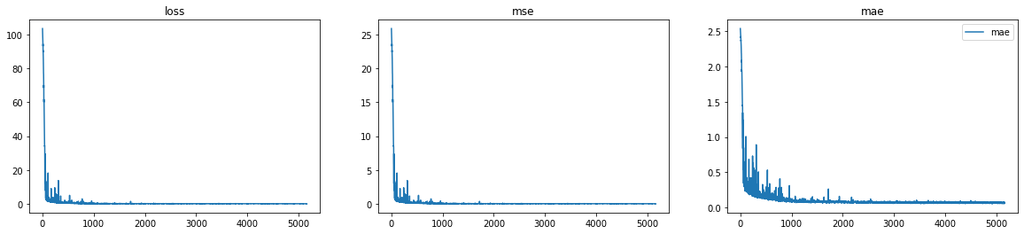

```
Train Loss: 0.13072948157787323
Train Mean square error: 0.03268
Train Mean absolute error: 0.07735
val results:
Mean square error: 0.22223
Mean absolute error: 0.22052
```

```python
model_conv3_32_16_norm = SalaryPredictor(conv_layers=3, third_layer_out=32, second_layer_out=16)
model_conv3_32_16_norm, model_conv3_32_16_norm_plot = train_model(model_conv3_32_16_norm)
```

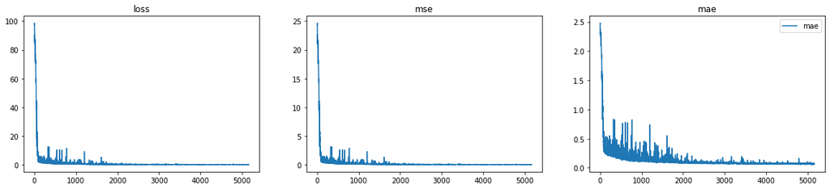

```
Train Loss: 1.3874311447143555
Train Mean square error: 0.34686
Train Mean absolute error: 0.24759
val results:
Mean square error: 0.67903
Mean absolute error: 0.40313
```

```python
model_conv3_32_32_norm = SalaryPredictor(conv_layers=3, third_layer_out=32, second_layer_out=32)
model_conv3_32_32_norm, model_conv3_32_32_norm_plot = train_model(model_conv3_32_32_norm)
```

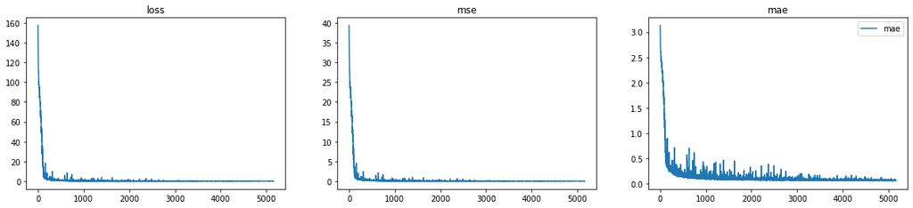

```
Train Loss: 0.06372454017400742
Train Mean square error: 0.01593
Train Mean absolute error: 0.05160
val results:
Mean square error: 0.20695
Mean absolute error: 0.21145
```

```python
model_conv3_16_32_norm = SalaryPredictor(conv_layers=3, third_layer_out=16, second_layer_out=32)
model_conv3_16_32_norm, model_conv3_16_32_norm_plot = train_model(model_conv3_16_32_norm)
```

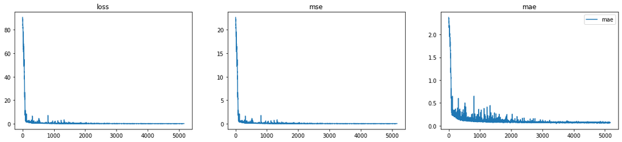

```
Train Loss: 0.05404707416892052
Train Mean square error: 0.01351
Train Mean absolute error: 0.04065
val results:
Mean square error: 0.11117
Mean absolute error: 0.14607
```

```python
model_conv3_norm = SalaryPredictor(conv_layers=3)
model_conv3_norm, model_conv3_norm_plot = train_model(model_conv3_norm)
```

Здесь заметно, что чем больше выход, тем хуже мы получаем результаты. Из сверточных сетей с 3мя слоями лучше всего та модель, где выходы везде 8. Хотя на train data почти такие же результаты у модели с выходами 16, 32, 8.

```python
# Early Stopping

def traindata(device, model, epochs, optimizer, loss_function, data_train, data_val):
    last_loss = 150
    patience = 2
    trigger_times = 0

    for epoch in range(1, epochs+1):
        for i, batch in tqdm.notebook.tqdm(enumerate(
              iterate_minibatches(
                      data_train,
                      batch_size=BATCH_SIZE,
                      device=DEVICE)),
                  total=len(data_train) // BATCH_SIZE):
          model.train()
          pred = model(batch)
          optimizer.zero_grad()
          loss = criterion(pred, batch[TARGET_COLUMN])
          loss.backward()
          optimizer.step()

          if i % 400 == 0 or i == (len(data_train) // BATCH_SIZE):
                print('[{}/{}, {}/{}] loss: {:.8}'.format(epoch, epochs, i, (len(data_train) // BATCH_SIZE), loss.item()))


        current_loss = validation(model, data_val, device, loss_function)
        print('The Current Loss:', current_loss)

        if current_loss > last_loss:
            trigger_times += 1
            print('Trigger Times:', trigger_times)

            if trigger_times >= patience:
                print('Early stopping!\nStart to test process.')
                return model

        else:
            print('trigger times: 0')
            trigger_times = 0

        last_loss = current_loss

    return model
```

```python
def validation(model, data_val, device, loss_function):

    model.eval()
    loss_total = n = 0

    with torch.no_grad():
      for i, batch in tqdm.notebook.tqdm(enumerate(
                iterate_minibatches(
                        data_val,
                        batch_size=BATCH_SIZE,
                        device=DEVICE)),
                    total=len(data_val) // BATCH_SIZE
            ):
            pred = model(batch)
            loss = criterion(pred, batch[TARGET_COLUMN])
            loss_total += loss.item()
            n += len(batch)

    return loss_total / n
```

```python
model = SalaryPredictor().to(DEVICE)
criterion = nn.MSELoss(reduction='mean')
optimizer = torch.optim.Adam(model.parameters(), lr=1e-3)

model = traindata(DEVICE, model, 15, optimizer, criterion, data_train, data_val)

print_metrics(model, data_val, name='val', batch_size=BATCH_SIZE, device=DEVICE)
```

```
[1/15, 0/1721] loss: 80.601402
[1/15, 400/1721] loss: 0.67825592
[1/15, 800/1721] loss: 0.3166509
[1/15, 1200/1721] loss: 0.57675129
[1/15, 1600/1721] loss: 0.22211102
[1/15, 1721/1721] loss: 3.4822311
```

```
The Current Loss: 0.33840185559044283
trigger times: 0
```

```
[2/15, 0/1721] loss: 0.2263076
[2/15, 400/1721] loss: 0.16534829
[2/15, 800/1721] loss: 0.27179584
[2/15, 1200/1721] loss: 0.15775317
[2/15, 1600/1721] loss: 0.16064157
[2/15, 1721/1721] loss: 0.25679791
```

```
The Current Loss: 0.07645255932584405
trigger times: 0
```

```
[3/15, 0/1721] loss: 0.12995821
[3/15, 400/1721] loss: 0.13038653
[3/15, 800/1721] loss: 0.17923172
[3/15, 1200/1721] loss: 0.14697374
[3/15, 1600/1721] loss: 0.086587794
[3/15, 1721/1721] loss: 0.0022040375
```

```
The Current Loss: 0.04535728793901702
trigger times: 0
```

```
[4/15, 0/1721] loss: 0.081625603
[4/15, 400/1721] loss: 0.11752785
[4/15, 800/1721] loss: 0.1178246
[4/15, 1200/1721] loss: 0.13284035
[4/15, 1600/1721] loss: 0.071493022
[4/15, 1721/1721] loss: 0.13811751
```

```
The Current Loss: 0.029086836409987882
trigger times: 0
```

```
[5/15, 0/1721] loss: 0.096977428
[5/15, 400/1721] loss: 0.092528492
[5/15, 800/1721] loss: 0.10841235
[5/15, 1200/1721] loss: 0.10529806
[5/15, 1600/1721] loss: 0.061866857
[5/15, 1721/1721] loss: 0.45723546
```

```
The Current Loss: 0.028851754943995427
trigger times: 0
```

```
[6/15, 0/1721] loss: 0.16125722
[6/15, 400/1721] loss: 0.10598388
[6/15, 800/1721] loss: 0.07503894
[6/15, 1200/1721] loss: 0.082514733
[6/15, 1600/1721] loss: 0.10705169
[6/15, 1721/1721] loss: 0.095989965
```

```
The Current Loss: 0.03053625998048422
Trigger Times: 1
```

```
[7/15, 0/1721] loss: 0.086328387
[7/15, 400/1721] loss: 0.092348337
[7/15, 800/1721] loss: 0.069278866
[7/15, 1200/1721] loss: 0.10202613
[7/15, 1600/1721] loss: 0.1123578
[7/15, 1721/1721] loss: 0.14644632
```

```
The Current Loss: 0.03596913627795099
Trigger Times: 2
Early stopping!
Start to test process.
val results:
Mean square error: 0.03610
Mean absolute error: 0.07492
```

```
(0.03609894712766012, 0.07491755485534668)
```

Ниже я пробовала разные значения параметра groups у сверточной сети:

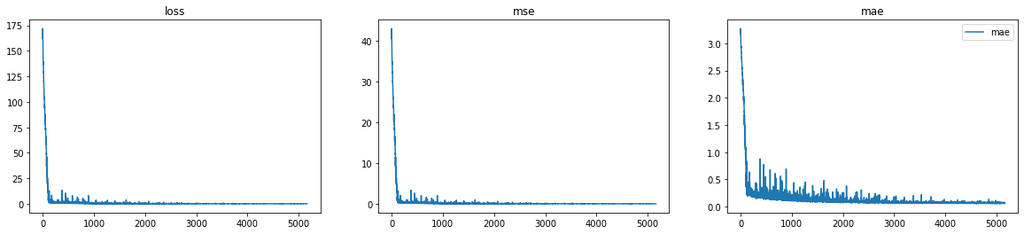

```
Train Loss: 0.7143697738647461
Train Mean square error: 0.17859
Train Mean absolute error: 0.17337
val results:
Mean square error: 0.11608
Mean absolute error: 0.15065
```

```python
model_with_two_groups = SalaryPredictor(groups=2)
model_with_two_groups, model_with_two_groups_plot = train_model(model_with_two_groups)
```

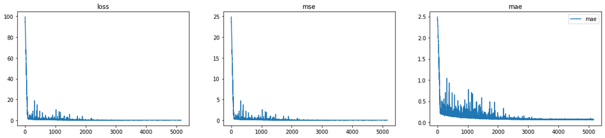

```
Train Loss: 0.07921008765697479
Train Mean square error: 0.01980
Train Mean absolute error: 0.06472
val results:
Mean square error: 0.03994
Mean absolute error: 0.07751
```

```python
model_with_four_groups = SalaryPredictor(groups=4)
model_with_four_groups, model_with_four_groups_plot = train_model(model_with_four_groups)
```

При параметре groups=4 в начале эксперимента наблюдается много скачков, как в MSE, так и в МАЕ, но результат очень хороший.

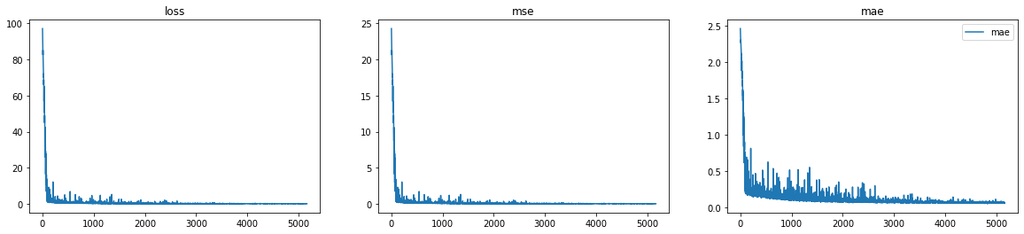

```
Train Loss: 0.05318066477775574
Train Mean square error: 0.01330
Train Mean absolute error: 0.05375
val results:
Mean square error: 0.06181
Mean absolute error: 0.10162
```

```python
model_with_eight_groups = SalaryPredictor(groups=8)
model_with_eight_groups, model_with_eight_groups_plot = train_model(model_with_eight_groups)
```

**2. Pooling слои стандартные (1 балла)**

Pooling подразумевает под собой сжатие матрицы, например, при сжатие 2х2 мы из 4 ячеек получаем только 1, это может быть максимальное число из 4 ячеек, может быть среднее. Все зависит от того, какой pooling мы применяем.

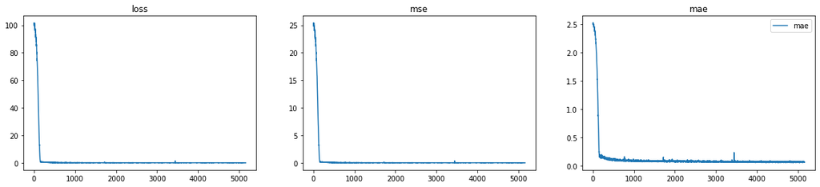

```
Train Loss: 0.059827666729688644
Train Mean square error: 0.01496
Train Mean absolute error: 0.05490
val results:
Mean square error: 0.02528
Mean absolute error: 0.06070
```

```python
# Cреднее по временной компоненте (исключая PAD символы)

model_avg_two_groups = SalaryPredictor(groups=2, pool=nn.AdaptiveAvgPool1d)
model_avg_two_groups, model_avg_two_groups_plot = train_model(model_avg_two_groups)
```

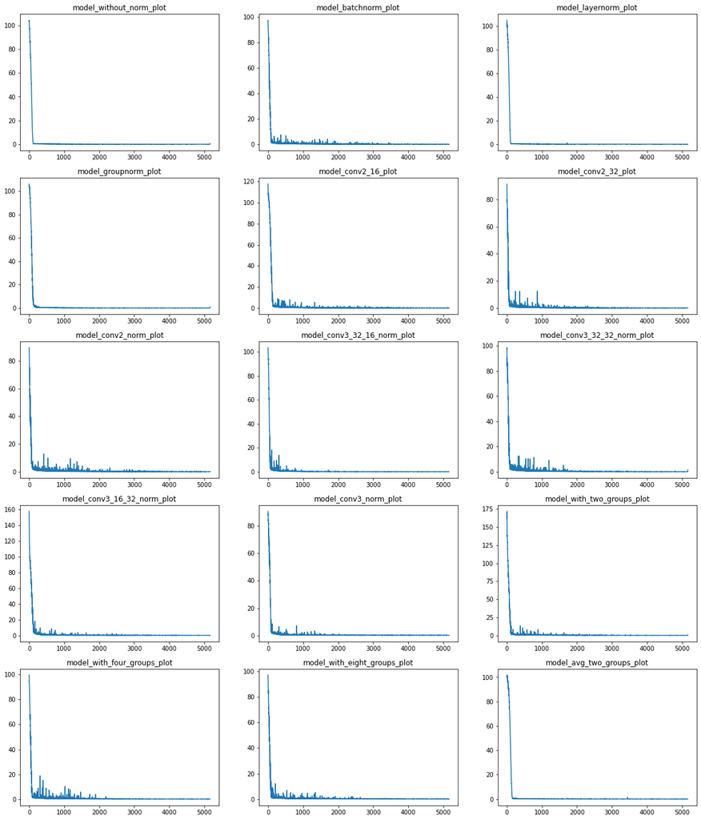

```python
fig, ax = plt.subplots(nrows=5, ncols=3, figsize=(20, 24))

ax[0,0].plot(model_without_norm_plot, label="loss")
ax[0,0].set_title('model_without_norm_plot')
ax[0,1].plot(model_batchnorm_plot, label="loss")
ax[0,1].set_title('model_batchnorm_plot')
ax[0,2].plot(model_layernorm_plot, label="loss")
ax[0,2].set_title('model_layernorm_plot')
ax[1,0].plot(model_groupnorm_plot, label="loss")
ax[1,0].set_title('model_groupnorm_plot')
ax[1,1].plot(model_conv2_16_plot, label="loss")
ax[1,1].set_title('model_conv2_16_plot')
ax[1,2].plot(model_conv2_32_plot, label="loss")
ax[1,2].set_title('model_conv2_32_plot')
ax[2,0].plot(model_conv2_norm_plot, label="loss")
ax[2,0].set_title('model_conv2_norm_plot')
ax[2,1].plot(model_conv3_32_16_norm_plot, label="loss")
ax[2,1].set_title('model_conv3_32_16_norm_plot')
ax[2,2].plot(model_conv3_32_32_norm_plot, label="loss")
ax[2,2].set_title('model_conv3_32_32_norm_plot')
ax[3,0].plot(model_conv3_16_32_norm_plot, label="loss")
ax[3,0].set_title('model_conv3_16_32_norm_plot')
ax[3,1].plot(model_conv3_norm_plot, label="loss")
ax[3,1].set_title('model_conv3_norm_plot')
ax[3,2].plot(model_with_two_groups_plot, label="loss")
ax[3,2].set_title('model_with_two_groups_plot')
ax[4,0].plot(model_with_four_groups_plot, label="loss")
ax[4,0].set_title('model_with_four_groups_plot')
ax[4,1].plot(model_with_eight_groups_plot, label="loss")
ax[4,1].set_title('model_with_eight_groups_plot')
ax[4,2].plot(model_avg_two_groups_plot, label="loss")
ax[4,2].set_title('model_avg_two_groups_plot')

plt.show()
```

**Выводы**: модель без нормализации, с LayerNorm & GroupNorm и Average Pooling имеют схожее поведение: они постепенно обучаются, не наблюдается скачков. Большие скачки наблюдались у моделей с 2-мя и 3-мя слоями, где выходы равны 32, а также у модели с параметром groups, равным 4. Остальные модели имеют похожее поведение.

**3. Используйте предобученные эмбеддинги (2 балла)**

```python
import gensim.downloader as api
```

```python
model_glove_twitter = api.load("glove-twitter-25")
```

```
[==================================================] 100.0% 104.8/104.8MB downloaded
```

```python
model_gigaword = api.load("glove-wiki-gigaword-100")
```

```
[==================================================] 100.0% 128.1/128.1MB downloaded
```

```python
weights = torch.FloatTensor(model_glove_twitter.vectors)
```

```python
embedding = nn.Embedding.from_pretrained(weights)
```

[figure not shown]

[output not shown]

```python
model_twitter_false_grad = SalaryPredictor(hid_size=25, pretrained=True, grad=False, weights=weights)
model_twitter_false_grad, model_twitter_false_grad_plot = train_model(model_twitter_false_grad)
```

[figure not shown]

[output not shown]

```python
model_twitter_true_grad = SalaryPredictor(hid_size=25, pretrained=True, grad=True, weights=weights)
model_twitter_true_grad, model_twitter_true_grad_plot = train_model(model_twitter_true_grad)
```

```python
weights_wiki = torch.FloatTensor(model_gigaword.vectors)
```

[figure not shown]

[output not shown]

```python
model_wiki_false_grad = SalaryPredictor(hid_size=100, pretrained=True, grad=False, weights=weights_wiki)
model_wiki_false_grad, model_wiki_false_grad_plot = train_model(model_wiki_false_grad)
```

[figure not shown]

[output not shown]

```python
model_wiki_true_grad = SalaryPredictor(hid_size=100, pretrained=True, grad=True, weights=weights_wiki)
model_wiki_true_grad, model_wiki_true_grad_plot = train_model(model_wiki_true_grad)
```

**4. Замените сверточные слои на рекуррентные (3 балла)**

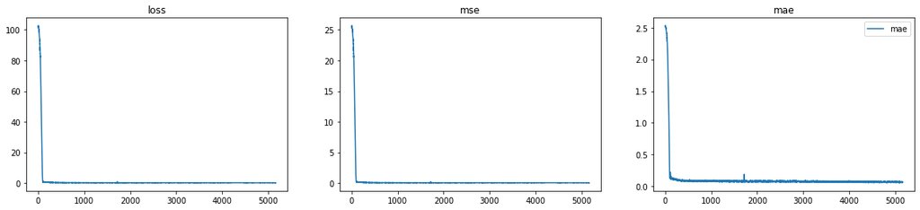

```
Train Loss: 0.013801111839711666
Train Mean square error: 0.00345
Train Mean absolute error: 0.02665
val results:
Mean square error: 0.16900
Mean absolute error: 0.18889
```

```python
model_lstm = SalaryPredictor(hid_size=12, bidirectional=False, layers=2, rnn=True, lstm_title=True, lstm_desc=True)
model_lstm, model_lstm_plot = train_model(model_lstm)
```

Я несколько раз прогоняла код с LSTM-моделью, сейчас видно, что на train data MSE & MAE результаты показывает лучше, но на валидационных хуже. Но иногда показатели и на валидационных были лучше. Судя по графикам, поведение модели напоминает модель без нормализации и с нормализацией GroupNorm, нет скачков, модель постепенно улучшает показатели.

```python
model = SalaryPredictor(hid_size=12, bidirectional=False, layers=2, rnn=True, lstm_title=True, lstm_desc=True)
criterion = nn.MSELoss(reduction='mean')
optimizer = torch.optim.Adam(model.parameters(), lr=1e-3)

model = traindata(DEVICE, model, 15, optimizer, criterion, data_train, data_val)

print_metrics(model, data_val, name='val', batch_size=BATCH_SIZE, device=DEVICE)
```

```
[1/15, 0/1721] loss: 101.88745
[1/15, 400/1721] loss: 0.30422172
[1/15, 800/1721] loss: 0.15530817
[1/15, 1200/1721] loss: 0.14734668
[1/15, 1600/1721] loss: 0.1698691
[1/15, 1721/1721] loss: 0.49220333
```

```
The Current Loss: 0.1539832915101821
trigger times: 0
```

```
[2/15, 0/1721] loss: 0.11734784
[2/15, 400/1721] loss: 0.15779491
[2/15, 800/1721] loss: 0.1147691
[2/15, 1200/1721] loss: 0.14222135
[2/15, 1600/1721] loss: 0.13084382
[2/15, 1721/1721] loss: 0.02953578
```

```
The Current Loss: 0.12442312688411523
trigger times: 0
```

```
[3/15, 0/1721] loss: 0.12859124
[3/15, 400/1721] loss: 0.10422103
[3/15, 800/1721] loss: 0.11083871
[3/15, 1200/1721] loss: 0.10069782
[3/15, 1600/1721] loss: 0.10740612
[3/15, 1721/1721] loss: 0.16686343
```

```
The Current Loss: 0.14405441241494069
Trigger Times: 1
```

```
[4/15, 0/1721] loss: 0.11969767
[4/15, 400/1721] loss: 0.11376823
[4/15, 800/1721] loss: 0.092939444
[4/15, 1200/1721] loss: 0.084011391
[4/15, 1600/1721] loss: 0.092331834
[4/15, 1721/1721] loss: 0.012335275
```

```
The Current Loss: 0.11721852868019293
trigger times: 0
```

```
[5/15, 0/1721] loss: 0.092182778
[5/15, 400/1721] loss: 0.11805511
[5/15, 800/1721] loss: 0.12745889
[5/15, 1200/1721] loss: 0.15019199
[5/15, 1600/1721] loss: 0.07553006
[5/15, 1721/1721] loss: 0.0097820302
```

```
The Current Loss: 0.17206115097117922
Trigger Times: 1
```

```
[6/15, 0/1721] loss: 0.080097154
[6/15, 400/1721] loss: 0.075222835
[6/15, 800/1721] loss: 0.087482348
[6/15, 1200/1721] loss: 0.10564497
[6/15, 1600/1721] loss: 0.093947113
[6/15, 1721/1721] loss: 0.14584391
```

```
The Current Loss: 0.14804186035568515
trigger times: 0
```

```
[7/15, 0/1721] loss: 0.098442167
[7/15, 400/1721] loss: 0.10006516
[7/15, 800/1721] loss: 0.13381498
[7/15, 1200/1721] loss: 0.078266799
[7/15, 1600/1721] loss: 0.09382154
[7/15, 1721/1721] loss: 0.439383
```

```
The Current Loss: 0.16076179353209832
Trigger Times: 1
```

```
[8/15, 0/1721] loss: 0.1131884
[8/15, 400/1721] loss: 0.093779802
[8/15, 800/1721] loss: 0.10217911
[8/15, 1200/1721] loss: 0.085371964
[8/15, 1600/1721] loss: 0.079231344
[8/15, 1721/1721] loss: 0.0073770829
```

```
The Current Loss: 0.22884944205482802
Trigger Times: 2
Early stopping!
Start to test process.
val results:
Mean square error: 0.22875
Mean absolute error: 0.22733
```

```
(0.22875179847081503, 0.22732569773991904)
```

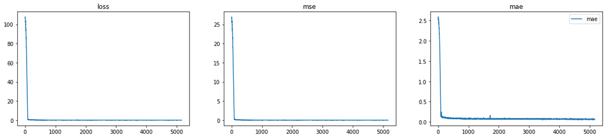

```
Train Loss: 0.0938885286450386
Train Mean square error: 0.02347
Train Mean absolute error: 0.07289
val results:
Mean square error: 0.34347
Mean absolute error: 0.28096
```

```python
model_gru = SalaryPredictor(hid_size=12, bidirectional=False, layers=2, rnn=True, gru_title=True, gru_desc=True)
model_gru, model_gru_plot = train_model(model_gru)
```

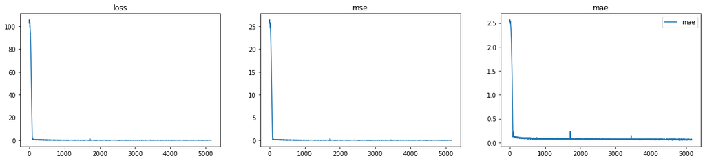

```
Train Loss: 0.5777967572212219
Train Mean square error: 0.14445
Train Mean absolute error: 0.15269
val results:
Mean square error: 0.27251
Mean absolute error: 0.24873
```

```python
# Рассматривается смесь рекуррентной и сверточной сетей

model_lstm_mix = SalaryPredictor(hid_size=12, bidirectional=False, layers=2, norm="None",
                                 rnn=True, lstm_title=True, lstm_desc=True, mix=True)
model_lstm_mix, model_lstm_mix_plot = train_model(model_lstm_mix)
```

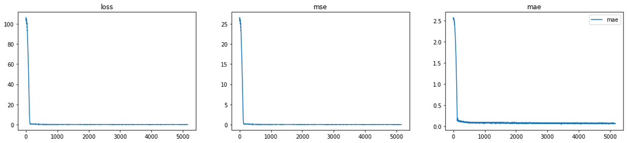

```
Train Loss: 0.05456255003809929
Train Mean square error: 0.01364
Train Mean absolute error: 0.05436
val results:
Mean square error: 0.40226
Mean absolute error: 0.30638
```

```python
# Рассматривается смесь рекуррентной и сверточной сетей с параметром groups=2

model_lstm_mix_two_groups = SalaryPredictor(hid_size=12, bidirectional=False, layers=2, norm="None",
                                            rnn=True, lstm_title=True, lstm_desc=True, mix=True, groups=2)
model_lstm_mix_two_groups, model_lstm_mix_two_groups_plot = train_model(model_lstm_mix_two_groups)
```

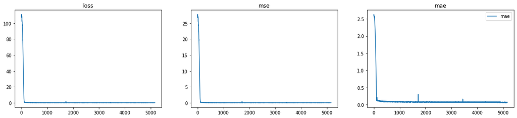

```
Train Loss: 0.31663191318511963
Train Mean square error: 0.07916
Train Mean absolute error: 0.12884
val results:
Mean square error: 0.24133
Mean absolute error: 0.23080
```

```python
# Рассматривается смесь рекуррентной и сверточной сетей с параметром groups=2 и нормализацией

model_lstm_mix_two_groups_batch = SalaryPredictor(hid_size=12, bidirectional=False, layers=2, norm="batch",
                                            rnn=True, lstm_title=True, lstm_desc=True, mix=True, groups=2)
model_lstm_mix_two_groups_batch, model_lstm_mix_two_groups_batch_plot = train_model(model_lstm_mix_two_groups_batch)
```

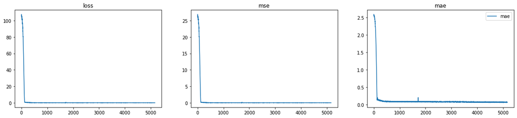

```
Train Loss: 0.14700479805469513
Train Mean square error: 0.03675
Train Mean absolute error: 0.07515
val results:
Mean square error: 0.07728
Mean absolute error: 0.11904
```

```python
# Рассматривается смесь рекуррентной и сверточной сетей

model_lstm_mix_batch = SalaryPredictor(hid_size=12, bidirectional=False, layers=2, norm="batch",
                                            rnn=True, lstm_title=True, lstm_desc=True, mix=True)
model_lstm_mix_batch, model_lstm_mix_batch_plot = train_model(model_lstm_mix_batch)
```

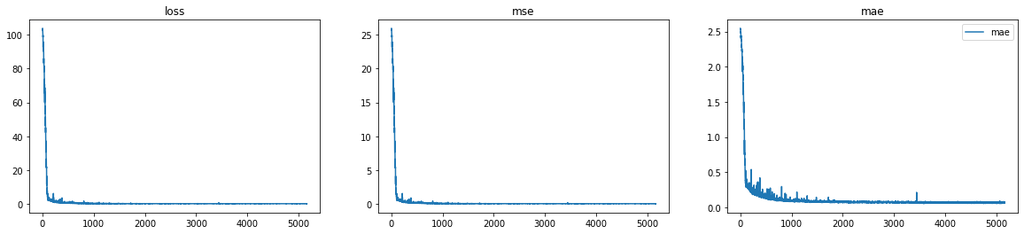

```
Train Loss: 0.26741841435432434
Train Mean square error: 0.06685
Train Mean absolute error: 0.10486
val results:
Mean square error: 0.15156
Mean absolute error: 0.17785
```

```python
# Для title используется сверточная нейросеть из двух слоев, для description - рекуррентная

model_lstm_desc = SalaryPredictor(hid_size=12, bidirectional=False, layers=2, norm="batch",
                                            rnn=True, lstm_title=False, lstm_desc=True)
model_lstm_desc, model_lstm_desc_plot = train_model(model_lstm_desc)
```

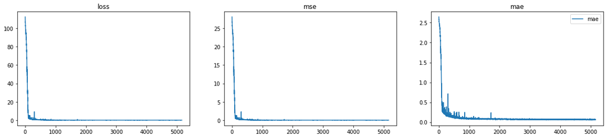

```
Train Loss: 0.2213677167892456
Train Mean square error: 0.05534
Train Mean absolute error: 0.10771
val results:
Mean square error: 0.13582
Mean absolute error: 0.16765
```

```python
# Для title используется сверточная нейросеть из одного слоя, для description - рекуррентная

model_lstm_desc_one = SalaryPredictor(hid_size=12, bidirectional=False, layers=1, norm="batch",
                                            rnn=True, lstm_title=False, lstm_desc=True)
model_lstm_desc_one, model_lstm_desc_one_plot = train_model(model_lstm_desc_one)
```

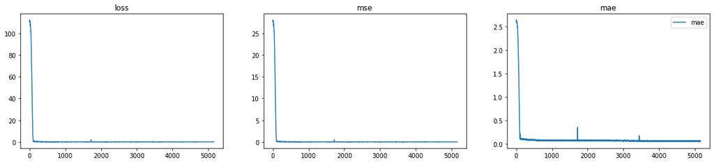

```
Train Loss: 0.6119824647903442
Train Mean square error: 0.15300
Train Mean absolute error: 0.16331
val results:
Mean square error: 0.67636
Mean absolute error: 0.40313
```

```python
# Двунаправленная рекуррентная сеть

model_lstm_fc6 = SalaryPredictor(hid_size=12, bidirectional=True, layers=2, rnn=True, lstm_title=True, lstm_desc=True, final_const=6)
model_lstm_fc6, model_lstm_fc6_plot = train_model(model_lstm_fc6)
```

Если сравнивать результаты однонаправленную и двунаправленную рекуррентные нейросети, то однонаправленная показывает результаты лучше. Я бы даже сказала, что двунаправленная показывает очень плохие результаты, если сопоставить ее с моделями ранее.

**5. Вытащите признаки из нейронной сети и используйте их в ансамбле деревьев решений. (2 балла)**

Я попыталась использовать Decision Tree & Random Forest в экспериментах ниже, но не удалось добиться лучшего результата, чем давали модели выше.

```python
activation = {}
def get_activation(name):
    def hook(model, input, output):
        activation[name] = output.detach()
    return hook
```

```python
train_batch = make_batch(data_train[:3000], device=torch.device('cuda'))

a = train_batch
b = a[TARGET_COLUMN]

fir = a['Categorical']
sec = a['FullDescription']
thi = a['Title']
```

```python
model = model_avg_two_groups # здесь я использую самую удачную модель на валидационных данных

model.register_forward_hook(get_activation('prefinal_predictor'))
output = model(train_batch)
activation['prefinal_predictor']
```

```
tensor([10.1406,  9.6994, 10.4341,  ..., 10.2688, 10.5331,  9.0589],
       device='cuda:0')
```

```python
weights_pred = activation['prefinal_predictor']
```

```python
from sklearn.ensemble import RandomForestRegressor
from sklearn.tree import DecisionTreeRegressor
```

```python
final_data = torch.cat(
            [fir, sec, thi], dim=1)
```

```python
weights_pred = weights_pred.cpu().numpy()
final_data = final_data.cpu().numpy()
```

```python
weights_pred.shape
```

```
(3000,)
```

```python
regr = RandomForestRegressor(max_depth=2, random_state=0)
regr.fit(final_data, b.cpu(), weights_pred.flatten())
```

```
RandomForestRegressor(max_depth=2, random_state=0)
```

```python
regr_dt = DecisionTreeRegressor(max_depth=2)
regr_dt.fit(final_data, b.cpu(), weights_pred.flatten())
```

```
DecisionTreeRegressor(max_depth=2)
```

```python
y_pred_dt = regr_dt.predict(final_data)
```

```python
y_pred = regr.predict(final_data)
```

```python
y_pred
```

```
array([10.30545787, 10.30958883, 10.30778785, ..., 10.31001225,
       10.30386828, 10.30323347])
```

```python
from sklearn.metrics import mean_squared_error
from sklearn.metrics import mean_absolute_error

print("Random Forest Results:")
print("MSE:", mean_squared_error(b.cpu(), y_pred))
print("MAE:", mean_absolute_error(b.cpu(), y_pred))

print("Decision Tree Results:")
print("MSE:", mean_squared_error(b.cpu(), y_pred_dt))
print("MAE:", mean_absolute_error(b.cpu(), y_pred_dt))
```

```
Random Forest Results:
MSE: 0.22083401009116074
MAE: 0.37330444834947485
Decision Tree Results:
MSE: 0.22469871018542825
MAE: 0.3755464041038153
```

Вероятно, я могла сделать что-то не так, но по результатам экспериментов, ансамбль из деревьев решений не дает хорошего результата.